## Часть 1. Предварительный анализ данных car2004

```r
library(kableExtra)
library(ppcor)
library(readr)
library(ggplot2)
library(hrbrthemes)
library(tidyverse)
library(readxl)
library(GGally)
library(psych)
library(plotly)
library(nortest)
library(summarytools)
library(scatterPlotMatrix)
library(viridis)
library(patchwork)
library(gridExtra)
library(ggpubr)
library(car)
library(e1071)
library(cowplot)
library(corrplot)

print_df <- function(df)
{
  df |>
    kable(format = "html") |>
    kable_styling() |>
    kableExtra::scroll_box(width = "100%", height = "100%")
}


create_ggpairs <- function(data, density_diag = TRUE, fig_width = 15, fig_height = 7) {
  if (density_diag) {
    ggpairs(data, diag = list(continuous = "densityDiag", discrete = "barDiag", na = "naDiag", mapping = aes(fill = "red")), fig.width = fig_width, fig.height = fig_height)
  } else {
    ggpairs(data, diag = list(continuous = "barDiag", mapping = aes(fill = "red")), fig.width = fig_width, fig.height = fig_height)
  }
}

plot_qq_graph <- function(data, column_name) {
  data <- data
  expected_quantiles <- qnorm(ppoints(length(data)))
  qqnorm(data, pch = 19, col = "deeppink")
  qqline(data, distribution = qnorm, lwd = 2, col = "limegreen")
  legend("topleft", legend = column_name, col = "deeppink", pch = 19)
}
```

## 1. Загрузка данных

```r
data <- read_excel("C:/Users/arina/Desktop/R/car2004.xls", na = "*")
colnames(data) <- gsub("-", "_", colnames(data))

head(data, 5) |>
 print_df()
```

| Name | Sport | SportUtil | Wagon | Minivan | Pickup | All_wheel | Rear_wheel | Retail | Dealer | Engine | Cylinders | Horsepower | CityMPG | HW_MPG | Weight | WheelBase | Length | Width |
| --- | --- | --- | --- | --- | --- | --- | --- | --- | --- | --- | --- | --- | --- | --- | --- | --- | --- | --- |
| Chevrolet Aveo 4dr | 0 | 0 | 0 | 0 | 0 | 0 | 0 | 11690 | 10965 | 1.6 | 4 | 103 | 28 | 34 | 2370 | 98 | 167 | 66 |
| Chevrolet Aveo LS 4dr hatch | 0 | 0 | 0 | 0 | 0 | 0 | 0 | 12585 | 11802 | 1.6 | 4 | 103 | 28 | 34 | 2348 | 98 | 153 | 66 |
| Chevrolet Cavalier 2dr | 0 | 0 | 0 | 0 | 0 | 0 | 0 | 14610 | 13697 | 2.2 | 4 | 140 | 26 | 37 | 2617 | 104 | 183 | 69 |
| Chevrolet Cavalier 4dr | 0 | 0 | 0 | 0 | 0 | 0 | 0 | 14810 | 13884 | 2.2 | 4 | 140 | 26 | 37 | 2676 | 104 | 183 | 68 |
| Chevrolet Cavalier LS 2dr | 0 | 0 | 0 | 0 | 0 | 0 | 0 | 16385 | 15357 | 2.2 | 4 | 140 | 26 | 37 | 2617 | 104 | 183 | 69 |

Количество пропущенных значений для каждого признака

```r
na_count <- colSums(is.na(data))
print(na_count)
```

```
##       Name      Sport  SportUtil      Wagon    Minivan     Pickup  All_wheel
##          0          0          0          0          0          0          0
## Rear_wheel     Retail     Dealer     Engine  Cylinders Horsepower    CityMPG
##          0          0          0          0          0          0         14
##     HW_MPG     Weight  WheelBase     Length      Width
##         14          2         18         26         28
```

## 2. Описание признаков

Частота мод

```r
modes<-summarize(data, across(Name:Width, function(x) max(table(x))))
print_df(modes)
```

| Name | Sport | SportUtil | Wagon | Minivan | Pickup | All_wheel | Rear_wheel | Retail | Dealer | Engine | Cylinders | Horsepower | CityMPG | HW_MPG | Weight | WheelBase | Length | Width |
| --- | --- | --- | --- | --- | --- | --- | --- | --- | --- | --- | --- | --- | --- | --- | --- | --- | --- | --- |
| 2 | 379 | 368 | 398 | 408 | 404 | 336 | 318 | 2 | 2 | 42 | 190 | 17 | 68 | 54 | 4 | 45 | 26 | 55 |

Количество уникальных значений по каждому признаку

```r
unique_counts <- sapply(data, function(x) n_distinct(x, na.rm = TRUE))
print(unique_counts)
```

```
##       Name      Sport  SportUtil      Wagon    Minivan     Pickup  All_wheel
##        425          2          2          2          2          2          2
## Rear_wheel     Retail     Dealer     Engine  Cylinders Horsepower    CityMPG
##          2        410        425         43          8        110         28
##     HW_MPG     Weight  WheelBase     Length      Width
##         32        347         39         61         18
```

*Комментарий.* Несмотря на то, что у Horsepower довольно большая частота мод, но уникальных значений примерно 25% от всего объема данных, поэтому я посчитала, что логичнее будет считать этот признак непрерывным.

В городском цикле обычно встречаются частые остановки, старты и пробки, что приводит к более частому использованию тормозов и ускорителей. Это может уменьшить экономию топлива.

В условиях шоссейного движения меньше остановок и меньше стартов, что может способствовать более высокой экономии топлива.

То есть ожидается, что HW_MPG > CityMPG.

16. *Weight* - Вес автомобиля в фунтах - **количественный непрерывный**
17. *WheelBase* - Расстояние между передними и задними колесами в дюймах - **количественный дискретный**
18. *Length* - Длина автомобиля в дюймах - **количественный дискретный**
19. *Width* - Ширина автомобиля в дюймах - **количественный дискретный**

Добавим еще два столбца, которые будут отвечать другому (то есть ни одному из представленных) типу кузова и переднему приводу (понадобятся для поиска зависимостей в пункте 5).

```r
data$Other <- ifelse(rowSums(data[c("Sport", "SportUtil", "Wagon", "Minivan", "Pickup")]) == 0, 1, 0)
data$Front_wheel <- ifelse(rowSums(data[c("All_wheel", "Rear_wheel")]) == 0, 1, 0)
```

Также добавим столбцы, отвечающие типу кузова и типу привода (тоже для поиска зависимостей в пункте 5).

*Комментарий.* Почему-то здесь считается, что “Sport” – это тоже тип кузова. Предположим, что это означает типы кузовов, наиболее характерные для спортивных автомобилей, например, Roadster. Тогда к Other мы отнесем Coupe, Sedan и Hatchback.

```r
data <- data %>%
  mutate(
    Body_type = case_when(
      Sport == 1 ~ 1,
      SportUtil == 1 ~ 2,
      Wagon == 1 ~ 3,
      Minivan == 1 ~ 4,
      Pickup == 1 ~ 5,
      Other == 1 ~ 6,
      TRUE ~ NA_integer_
    )
  )

data <- data %>%
  mutate(
    Wheel_type = case_when(
      All_wheel == 1 ~ 1,
      Rear_wheel == 1 ~ 2,
      Front_wheel == 1 ~ 3,
      TRUE ~ NA_integer_
    )
  )
```

## 3. Симметричность

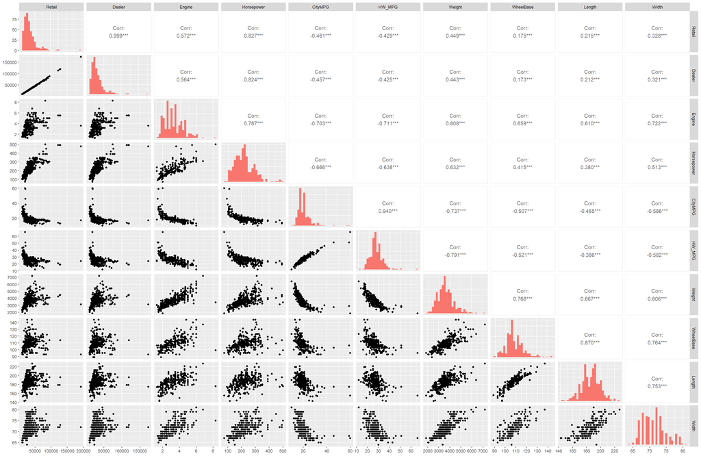

```r
data_select <- data %>% select(-Name, -Sport, -SportUtil,-Wagon, -Minivan, -Pickup, -All_wheel, -Rear_wheel, -Front_wheel, -Other, -Cylinders, -Body_type, -Wheel_type)

create_ggpairs(data_select, density_diag = FALSE)
```

Наблюдения Retail,Dealer,Engine,Horsepower,CityMPG,HW_MPG, Weight, WheelBase имеют хвост вправо, прологарифмируем их и построим графики зависимостей признаков.

## 4. Графики зависимостей признаков

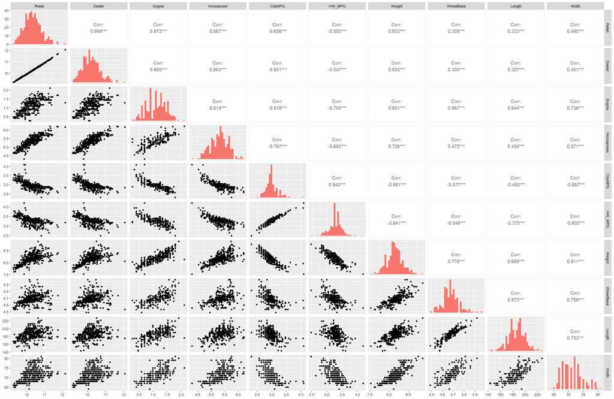

```r
data_log <- data %>%
  mutate_at(vars(Retail,Dealer,Engine,Horsepower,CityMPG,HW_MPG, Weight, WheelBase), ~log(.))

data_select <- data_log %>% select(-Name, -Sport, -SportUtil,-Wagon, -Minivan, -Pickup, -All_wheel, -Rear_wheel, -Front_wheel, -Other, -Cylinders, -Body_type, -Wheel_type)

create_ggpairs(data_select, density_diag = FALSE)
```

## 5. Поиск outliers

Так как наблюдений с неизвестными MPG и Weight не так много (14 и 2), то уберем их пока из рассмотрения, так как они мешают увидеть выбросы на графиках.

```r
data_log <- data_log %>%
  select(-c(Sport, SportUtil, Wagon, Minivan, Pickup, All_wheel, Rear_wheel, Cylinders), everything())

data_clear <- data_log %>%
  filter(!is.na(Weight) & !is.na(CityMPG))

categories <- list( NULL, NULL, NULL, NULL, NULL, NULL, NULL, NULL, NULL, NULL, c(0,1), c(0,1), c(1, 2, 3, 4, 5, 6), c(1, 2, 3), c(0,1), c(0,1), c(0,1), c(0,1), c(0,1), c(0,1), c(0,1), c(-1, 3, 4, 5, 6, 8, 10, 12))
data_clear |>
  select(-Name) |>
  scatterPlotMatrix(regressionType = 1,
                        corrPlotType = "Text",
                        categorical = categories,
                        plotProperties = list(noCatColor = "Indigo"),
                        controlWidgets = TRUE,
                        height = 1200, width = 1250)
```

[interactive chart not shown]

## Выбросы по CityMPG

```r
out1 <- data_clear %>%
  filter(CityMPG >= 3.6 | CityMPG <= 2.4 | (Retail >= 11.7 & CityMPG <= 2.9))

print_df(out1)
```

| Name | Retail | Dealer | Engine | Horsepower | CityMPG | HW_MPG | Weight | WheelBase | Length | Width | Other | Front_wheel | Body_type | Wheel_type | Sport | SportUtil | Wagon | Minivan | Pickup | All_wheel | Rear_wheel | Cylinders |
| --- | --- | --- | --- | --- | --- | --- | --- | --- | --- | --- | --- | --- | --- | --- | --- | --- | --- | --- | --- | --- | --- | --- |
| Honda Civic Hybrid 4dr manual (gas/electric) | 9.910463 | 9.822874 | 0.3364722 | 4.532599 | 3.828641 | 3.931826 | 7.912789 | 4.634729 | 175 | 68 | 1 | 1 | 6 | 3 | 0 | 0 | 0 | 0 | 0 | 0 | 0 | 4 |
| Honda Insight 2dr (gas/electric) | 9.857967 | 9.793170 | 0.6931472 | 4.290459 | 4.094345 | 4.189655 | 7.522941 | 4.553877 | 155 | 67 | 1 | 1 | 6 | 3 | 0 | 0 | 0 | 0 | 0 | 0 | 0 | 3 |
| Toyota Prius 4dr (gas/electric) | 9.928668 | 9.848292 | 0.4054651 | 4.700480 | 4.077537 | 3.931826 | 7.969012 | 4.663439 | 175 | 68 | 1 | 1 | 6 | 3 | 0 | 0 | 0 | 0 | 0 | 0 | 0 | 4 |
| Volkswagen Jetta GLS TDI 4dr | 9.954893 | 9.885222 | 0.6418539 | 4.605170 | 3.637586 | 3.828641 | 8.007367 | 4.595120 | 172 | 68 | 1 | 1 | 6 | 3 | 0 | 0 | 0 | 0 | 0 | 0 | 0 | 4 |
| Mercedes-Benz CL600 2dr | 11.763061 | 11.691908 | 1.7047481 | 6.200509 | 2.564949 | 2.944439 | 8.405815 | 4.736198 | 196 | 73 | 1 | 0 | 6 | 2 | 0 | 0 | 0 | 0 | 0 | 0 | 1 | 12 |
| Mercedes-Benz SL55 AMG 2dr | 11.709889 | 11.638571 | 1.7047481 | 6.200509 | 2.639057 | 3.044522 | 8.351139 | NA | 179 | 72 | 0 | 0 | 1 | 2 | 1 | 0 | 0 | 0 | 0 | 0 | 1 | 8 |
| Mercedes-Benz SL600 convertible 2dr | 11.749341 | 11.677202 | 1.7047481 | 6.200509 | 2.564949 | 2.944439 | 8.395929 | NA | 179 | 72 | 0 | 0 | 1 | 2 | 1 | 0 | 0 | 0 | 0 | 0 | 1 | 12 |
| Porsche 911 GT2 2dr | 12.167670 | 12.064279 | 1.2809338 | 6.167516 | 2.833213 | 3.178054 | 8.049108 | 4.532599 | 175 | 72 | 0 | 0 | 1 | 2 | 1 | 0 | 0 | 0 | 0 | 0 | 1 | 6 |
| Hummer H2 | 10.819678 | 10.732367 | 1.7917595 | 5.755742 | 2.302585 | 2.484907 | 8.764053 | 4.812184 | 190 | 81 | 0 | 0 | 2 | 1 | 0 | 1 | 0 | 0 | 0 | 1 | 0 | 8 |

**Высокое mpg**

У первых трех автомобилей очень высокие показатели mpg. Это связоно с тем, что они являются гибридными автомобилями (используют комбинацию бензинового двигателя и электрической системы), это повышает эффективность топлива. В датасете больше нет гибридных автомобилей, поэтому, удалим их.

Volkswagen Jetta GLS TDI 4dr известен своей высокой экономичностью в расходе топлива. Это связано с использованием технологии TDI (турбодизельный двигатель с прямым впрыском топлива). Эта технология позволяет эффективнее сжигать топливо, улучшает экономию топлива, поэтому его mpg тоже достаточно высокий. Таких автомобилей также больше нет в датасете, поэтому, можем убрать его из рассмотрения.

**Низкое mpg**

Низкие показатели связаны с тем, что Hummer H2 является внедорожником, а они не ориентированы на экономию топлива. Также у этого автомобиля очень высокий вес (он являтся самым тяжелым автомобилем в выборке), что также влияет на низкие показатели mpg.

**Высокая цена и довольно низкое mpg**

Porsche 911 GT2 – спортивный автомобиль. Видно, что он не только по Retail и MPG является выбросом, но и по Horsepower (477 (не в log шкале) – это очень много, по сравнению с остальными автомобилями).

Оставшиеся три автомобиля – мерседесы. Mercedes-Benz CL600 2dr имеет тип кузова Coupe, а Mercedes-Benz SL55 AMG 2dr, Mercedes-Benz SL600 convertible 2dr – спортивные автомобили с типами кузова Roadster. Эти автомобили спроектированы для предоставления высокого уровня комфорта и роскоши, и первостепенное внимание в них не уделено экономии топлива. Их цена действительно является очень большой (если посмотреть на Retail vs Dealer, то они будут отдаленнымии точками от всех остальных наблюдений вместе с поршем).

```r
data_clear <- data_clear %>%
  filter(!(CityMPG >= 3.6 | CityMPG <= 2.4 | (Retail >= 11.7 & CityMPG <= 2.9)))
```

## Выбросы по HW_MPG и Engine

```r
out2 <- data_clear %>%
  filter(Engine <= 0.3 | HW_MPG <= 2.7 | (Engine >= 1.7 & Weight <= 8.1))

print_df(out2)
```

| Name | Retail | Dealer | Engine | Horsepower | CityMPG | HW_MPG | Weight | WheelBase | Length | Width | Other | Front_wheel | Body_type | Wheel_type | Sport | SportUtil | Wagon | Minivan | Pickup | All_wheel | Rear_wheel | Cylinders |
| --- | --- | --- | --- | --- | --- | --- | --- | --- | --- | --- | --- | --- | --- | --- | --- | --- | --- | --- | --- | --- | --- | --- |
| Chevrolet Corvette 2dr | 10.70403 | 10.57306 | 1.7404662 | 5.857933 | 2.890372 | 3.218876 | 8.085179 | 4.653960 | 180 | 74 | 0 | 0 | 1 | 2 | 1 | 0 | 0 | 0 | 0 | 0 | 1 | 8 |
| Chevrolet Corvette convertible 2dr | 10.85002 | 10.71870 | 1.7404662 | 5.857933 | 2.890372 | 3.218876 | 8.085795 | 4.653960 | 180 | 74 | 0 | 0 | 1 | 2 | 1 | 0 | 0 | 0 | 0 | 0 | 1 | 8 |
| Mazda RX-8 4dr automatic | 10.15425 | 10.07719 | 0.2623643 | 5.283204 | 2.890372 | 3.218876 | 8.023880 | 4.663439 | 174 | NA | 0 | 0 | 1 | 2 | 1 | 0 | 0 | 0 | 0 | 0 | 1 | -1 |
| Mazda RX-8 4dr manual | 10.21097 | 10.13377 | 0.2623643 | 5.472271 | 2.890372 | 3.178054 | 8.015988 | 4.663439 | 174 | NA | 0 | 0 | 1 | 2 | 1 | 0 | 0 | 0 | 0 | 0 | 1 | -1 |
| Mercedes-Benz G500 | 11.24987 | 11.17801 | 1.6094379 | 5.676754 | 2.564949 | 2.639057 | 8.598404 | 4.718499 | 186 | 71 | 0 | 0 | 2 | 1 | 0 | 1 | 0 | 0 | 0 | 1 | 0 | 8 |

Mazda RX-8 4dr automatic и Mazda RX-8 4dr manual с очень маленьким объемом двигателя, но при этом хорошими показателями mpg – автомобили с роторным двигателем, который отличается от типичных поршневых двигателей и обладает рядом особенностей, которые могут влиять на экономию топлива и производительность. Так как автомобилей с таким типом двигателей только 2 в выборке, уберем их из рассмотрения.

Mercedes-Benz G500 с очень низким показателем mpg – внедорожник. Он также является довольно тяжжелым, поэтому расход топлива уведичивается, а значит mpg будет маленьким.

```r
 data_clear <- data_clear %>%
  filter(!(Engine <= 0.3 | HW_MPG <= 2.7 | (Engine >= 1.7 & Weight <= 8.1)))
```

Снова построим график зависимостей.

```r
data_clear |>
  select(-Name) |>
  scatterPlotMatrix(regressionType = 1,
                        corrPlotType = "Text",
                        categorical = categories,
                        plotProperties = list(noCatColor = "Indigo"),
                        controlWidgets = TRUE,
                        height = 1200, width = 1250)
```

[interactive chart not shown]

Временно удалим все строки с NA, чтобы посмотреть есть ли выбросы у WheelBase, Length, Width.

Снова построим график зависимостей.

```r
data_clear_na <- na.omit(data_clear)

data_clear_na |>
  select(-Name) |>
  scatterPlotMatrix(regressionType = 1,
                        corrPlotType = "Text",
                        categorical = categories,
                        plotProperties = list(noCatColor = "Indigo"),
                        controlWidgets = TRUE,
                        height = 1200, width = 1250)
```

[interactive chart not shown]

Есть некоторые выделяющиеся наблюдения, но по остальным признакам они таковыми не являются, поэому выбросами считать их не будем.

## 6. Неоднородности

**Неоднородности из-за внедорожников**

Есть небольшая неодродость у Horsepower vs MPG, Horsepower vs Weight, MPG vs Retail (Dealer), Weight vs Retail (Dealer).

1. Horsepower vs MPG, Horsepower vs Weight

   Объясняется наличием внедорожников, которые, как правило, оснащены мощными двигателями, что позволяет им разгоняться до высоких скоростей.Но mpg маленький в силу их большого веса.
2. MPG vs Retail (Dealer), Weight vs Retail (Dealer)

Объясняется тем, что у внедорожников меньше mpg в силу их большого размера и веса, но при этом на них высокий спрос из-за их универсальности и вместительности.

**Неоднородности из-за спортивных автомобилей**

Также если рассмотреть скаттерплоты по Weight, выбрав в качестве категоризующей переменной Sport, можно заметить, что вес спртивных машин меньше по сравнению с остальными, при этом при одном и том же c остальными машинами Weight Retail (Dealer), Horsepower, Engine будут у спортивных машин больше, а mpg будет меньше.

Если рассмотреть скаттерплоты с удаленными NA, то можно заметить, что по WheelBase vs Retail (Dealer), Horsepower, Engine, mpg спортивные автомобили тоже образуют неоднородность: при одинаковом с остальными машинами WheelBase у спортивных Retail (Dealer), Horsepower, Engine будут больше, при этом mpg будет меньше.

## Часть 2. О виде распределений и о сравнении распределений

## 1. Визуальная разница между типами машин в зависимости от цены продажи

Машины можно классифицировать по типу кузова (Sport, SportUtil, Wagon, Minivan, Pickup, Other), по типу привода (All_wheel, Rear_wheel, Front_wheel), по количеству цилиндров (-1, 3, 4, 5, 6, 8, 10, 12).

Посчитаем, сколько всего автомобилей подходят под каждую категорию:

```r
body_type <- colSums(data_clear[c("Sport", "SportUtil", "Wagon", "Minivan", "Pickup", "Other")] == 1, na.rm = TRUE)
body_type <- data.frame(Body_Type = names(body_type), Freq = as.vector(body_type))
row.names(body_type) <- NULL
print_df(body_type)
```

| Body_Type | Freq |
| --- | --- |
| Sport | 40 |
| SportUtil | 57 |
| Wagon | 29 |
| Minivan | 20 |
| Pickup | 23 |
| Other | 229 |

```r
wheel_type <- colSums(data_clear[c("All_wheel", "Rear_wheel", "Front_wheel")] == 1, na.rm = TRUE)
wheel_type <- data.frame(Wheel_Type = names(wheel_type), Freq = as.vector(wheel_type))
row.names(wheel_type) <- NULL
print_df(wheel_type)
```

| Wheel_Type | Freq |
| --- | --- |
| All_wheel | 87 |
| Rear_wheel | 100 |
| Front_wheel | 211 |

```r
cylinders_type<-table(Cylinders = data_clear$Cylinders)
print_df(cylinders_type)
```

| Cylinders | Freq |
| --- | --- |
| 4 | 126 |
| 5 | 7 |
| 6 | 187 |
| 8 | 78 |

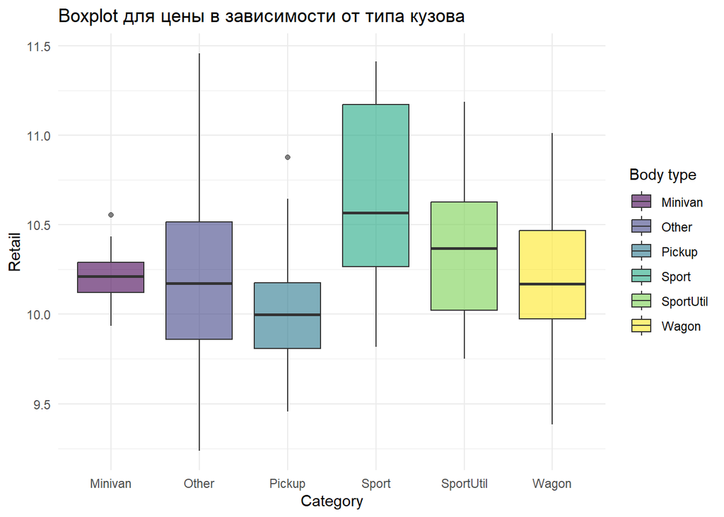

```r
plot1 <- data_clear %>%
  filter(SportUtil == 1 | Wagon == 1 | Minivan == 1 | Pickup == 1 | Sport == 1 | Other == 1) %>%
  mutate(Category = ifelse(SportUtil == 1, "SportUtil",
                           ifelse(Wagon == 1, "Wagon",
                                  ifelse(Minivan == 1, "Minivan",
                                         ifelse(Pickup == 1, "Pickup",
                                                 ifelse(Sport == 1, "Sport",
                                                         ifelse(Other == 1, "Other", NA))))))) %>%
  ggplot(aes(x = Category, y = Retail, fill = Category)) +
  geom_boxplot(alpha = 0.6) +
  theme_minimal() +
  labs(title = "Boxplot для цены в зависимости от типа кузова", x = "Category", y = "Retail") +
  scale_fill_viridis_d(name = "Body type")


plot1
```

Из графиков видно, что медианная стоимость спортивных машин и внедорожников выше, чем у машин с другим типом кузова.

Самые дешевые машины – пикапы. Более дорогие универсалы, other и минивэны. При этом у категории other самый большой разброс значений, что неудивительно, так как точно неизвестно, машины с каким типом кузова в нее входят, в ней могут встретиться как Sedan или Hatchback (считаются самыми дешевыми машинами), так и Coupe (более дорогие машины).

## Стоимость в зависимости от типа привода для групп Sport, SportUtil и группы из оставшихся типов кузова

Так как спортивные машины и внедорожники создают неоднородность в данных, то будем рассматривать эти группы отдельно от остальных машин.

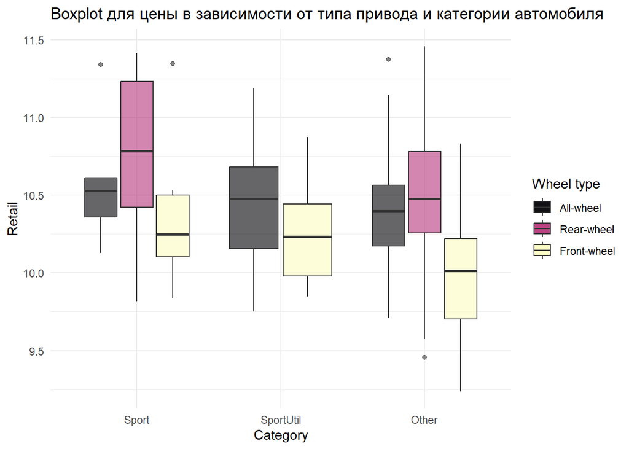

```r
data_clear <- data_clear %>%
  mutate(Wheel_type = factor(Wheel_type, labels = c("All-wheel", "Rear-wheel", "Front-wheel")))

sport_data <- data_clear %>%
  filter(Sport == 1)

sport_util_data <- data_clear %>%
  filter(SportUtil == 1)

other_cars_data <- data_clear %>%
  filter(Sport == 0 & SportUtil == 0)

ggplot() +
  geom_boxplot(data = sport_data, aes(x = factor(1), y = Retail, fill = Wheel_type), alpha = 0.6) +
  geom_boxplot(data = sport_util_data, aes(x = factor(2), y = Retail, fill = Wheel_type), alpha = 0.6) +
  geom_boxplot(data = other_cars_data, aes(x = factor(3), y = Retail, fill = Wheel_type), alpha = 0.6) +
  scale_x_discrete(labels = c("Sport", "SportUtil", "Other")) +
  scale_fill_viridis(discrete = TRUE, alpha = 0.6, option = "magma", name = "Wheel type") +
  theme_minimal() +
  labs(title = "Boxplot для цены в зависимости от типа привода и категории автомобиля", x = "Category", y = "Retail")
```

Среди всех групп самыми дешевыми являются переднеприводные автомобили. При этом в категории other переднеприводные машины стоят намного дешевле, чем полноприводные и заднеприводные. Также стоимость переднеприводных машин среди спортивных и внедорожников на первый взгляд примерно одинакова.

**Почему заднеприводные автомобили дороже полноприводных**

Раскрасим scatterPlotMatrix по типу привода. Для этого нужно в Use Z Axis выбрать Wheel_type.

Если мы посмотри на скаттерплот Retail vs mpg, то при одинаковой цене у заднеприводных автомобилей mpg будет больше, чем у полноприводных.

Также, если посмотрим на скаттерплот Horsepower vs mpg, то при одинаковом количестве лощадиных сил mpg у заднеприводных будет больше, чем у полноприводных.

То есть более высокую цену на заднеприводные автомобили можно объяснить тем, что у них выше mpg, а значит автомобиль будет проезжать большее расстояние на одном галлоне топлива, что является признаком более эффективного использования топлива.

Построим boxplot по mpg в зависимости от типа привода.

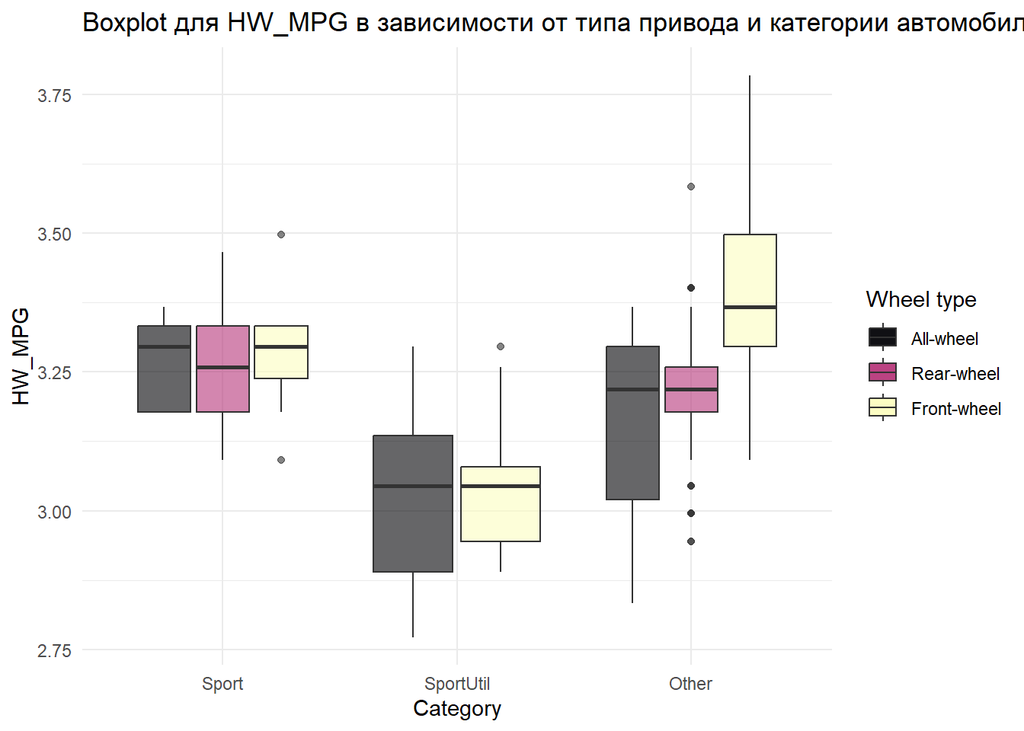

```r
ggplot() +
  geom_boxplot(data = sport_data, aes(x = factor(1), y = HW_MPG, fill = Wheel_type), alpha = 0.6) +
  geom_boxplot(data = sport_util_data, aes(x = factor(2), y = HW_MPG, fill = Wheel_type), alpha = 0.6) +
  geom_boxplot(data = other_cars_data, aes(x = factor(3), y = HW_MPG, fill = Wheel_type), alpha = 0.6) +
  scale_x_discrete(labels = c("Sport", "SportUtil", "Other")) +
  scale_fill_viridis(discrete = TRUE, alpha = 0.6, option = "magma", name = "Wheel type") +
  theme_minimal() +
  labs(title = "Boxplot для HW_MPG в зависимости от типа привода и категории автомобиля", x = "Category", y = "HW_MPG")
```

Картинка получилась интересной, потому что в категории Sport заднеприводные автомобили имеют меньшее медианное значение mpg, чем полноприводные автомобили. В категории other по медиане полноприводные получились равны заднеприводным, но разброс значений у полноприводных больше.

Посмотри также на скаттерплот Retail vs Weight. При равной цене вес заднеприводных будет меньше, чем полноприводных. Низкий вес влияет на эффективность топлива (расход будет меньше). У автомобилей с низким весом лучше управляемость, эффективная система торможения и более короткий тормозной путь.

Построим boxplot по Weight в зависимости от типа привода.

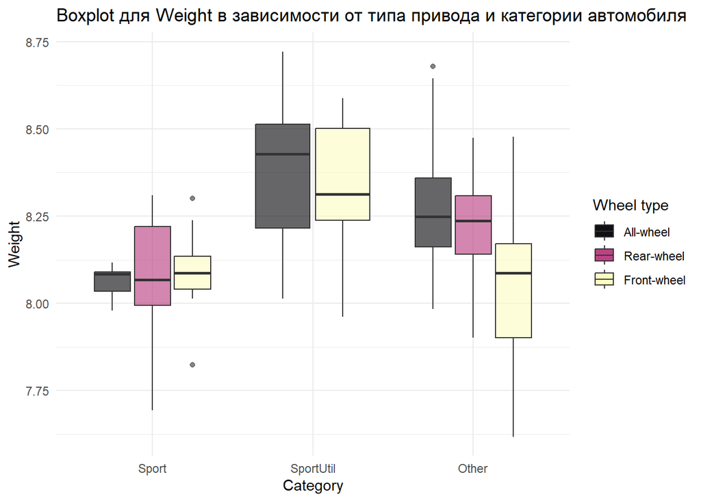

```r
ggplot() +
  geom_boxplot(data = sport_data, aes(x = factor(1), y = Weight, fill = Wheel_type), alpha = 0.6) +
  geom_boxplot(data = sport_util_data, aes(x = factor(2), y = Weight, fill = Wheel_type), alpha = 0.6) +
  geom_boxplot(data = other_cars_data, aes(x = factor(3), y = Weight, fill = Wheel_type), alpha = 0.6) +
  scale_x_discrete(labels = c("Sport", "SportUtil", "Other")) +
  scale_fill_viridis(discrete = TRUE, alpha = 0.6, option = "magma", name = "Wheel type") +
  theme_minimal() +
  labs(title = "Boxplot для Weight в зависимости от типа привода и категории автомобиля", x = "Category", y = "Weight")
```

Боксплоты подтверждают это предположение. У заднеприводных медианное значение веса на немного, но меньше медианного значения полноприводных.

Проверим по критериям.

Количество спортивных полноприводных и заднеприводных.

```r
count_rear_wheel_s <- sum(sport_data$Rear_wheel == 1)
count_rear_wheel_s
```

```
## [1] 27
```

```r
count_all_wheel_s <- sum(sport_data$All_wheel == 1)
count_all_wheel_s
```

```
## [1] 5
```

Количество полноприводных и заднеприводных в группе other.

```r
count_count_rear_wheel_o <- sum(other_cars_data$Rear_wheel == 1)
count_count_rear_wheel_o
```

```
## [1] 73
```

```r
count_all_wheel_o <- sum(other_cars_data$All_wheel == 1)
count_all_wheel_o
```

```
## [1] 47
```

Спортивных автомобилей очень мало, поэтому проверим равенство медиан с помощью непараметрического теста.

```r
rear_wheel_subset <- subset(other_cars_data, Rear_wheel == 1)
all_wheel_subset <- subset(other_cars_data, All_wheel == 1)

rear_wheel_weights <- rear_wheel_subset$Weight
all_wheel_weights <- all_wheel_subset$Weight

ks.test(rear_wheel_weights, all_wheel_weights)
```

```
##
##  Exact two-sample Kolmogorov-Smirnov test
##
## data:  rear_wheel_weights and all_wheel_weights
## D = 0.13815, p-value = 0.566
## alternative hypothesis: two-sided
```

Нет оснований отвергнуть гипотезу о том, что в групппе other одинаковое распределение веса для заднего и полного привода соответственно.

```r
wilcox.test(rear_wheel_weights, all_wheel_weights)
```

```
##
##  Wilcoxon rank sum test with continuity correction
##
## data:  rear_wheel_weights and all_wheel_weights
## W = 1578, p-value = 0.4614
## alternative hypothesis: true location shift is not equal to 0
```

```r
t.test(rear_wheel_weights, all_wheel_weights)
```

```
##
##  Welch Two Sample t-test
##
## data:  rear_wheel_weights and all_wheel_weights
## t = -1.3319, df = 80.785, p-value = 0.1866
## alternative hypothesis: true difference in means is not equal to 0
## 95 percent confidence interval:
##  -0.08914587  0.01765485
## sample estimates:
## mean of x mean of y
##  8.230547  8.266293
```

Оба теста показывают, что нет основания отвергать гипотезу о равенстве веса в группах.

```r
rear_wheel_subset <- subset(sport_data, Rear_wheel == 1)
all_wheel_subset <- subset(sport_data, All_wheel == 1)

rear_wheel_weights <- rear_wheel_subset$Weight
all_wheel_weights <- all_wheel_subset$Weight

ks.test(rear_wheel_weights, all_wheel_weights)
```

```
##
##  Exact two-sample Kolmogorov-Smirnov test
##
## data:  rear_wheel_weights and all_wheel_weights
## D = 0.37037, p-value = 0.4948
## alternative hypothesis: two-sided
```

Нет оснований отвергнуть гипотезу о том, что в групппе sport одинаковое распределение веса для заднего и полного привода соответственно.

```r
wilcox.test(rear_wheel_weights, all_wheel_weights)
```

```
##
##  Wilcoxon rank sum test with continuity correction
##
## data:  rear_wheel_weights and all_wheel_weights
## W = 72, p-value = 0.8355
## alternative hypothesis: true location shift is not equal to 0
```

```r
t.test(rear_wheel_weights, all_wheel_weights)
```

```
##
##  Welch Two Sample t-test
##
## data:  rear_wheel_weights and all_wheel_weights
## t = 0.36563, df = 19.778, p-value = 0.7185
## alternative hypothesis: true difference in means is not equal to 0
## 95 percent confidence interval:
##  -0.06812523  0.09705805
## sample estimates:
## mean of x mean of y
##  8.075413  8.060947
```

Оба теста показывают, что нет основания отвергать гипотезу о равенстве веса в группах.

## Равенство цен на переднеприводные автомобили в группах Sport и SportUtil

Проверим гипотезу о том, что цена на спортивные автомобили с передним приводом равна цене внедорожников с передним приводом.

Посчитаем количество наблюдений в рассматриваемых группах.

```r
count_sport_data <- nrow(sport_data)
count_sport_data
```

```
## [1] 40
```

```r
count_sport_util_data <- nrow(sport_util_data)
count_sport_util_data
```

```
## [1] 57
```

При этом переднеприводных машин

```r
count_front_wheel_s <- sum(sport_data$Front_wheel == 1)
count_front_wheel_s
```

```
## [1] 8
```

```r
count_front_wheel_su <- sum(sport_util_data$Front_wheel == 1)
count_front_wheel_su
```

```
## [1] 22
```

Для начала проверим нормальность для каждой группы.

**Передний привод для спортивных автомобилей**

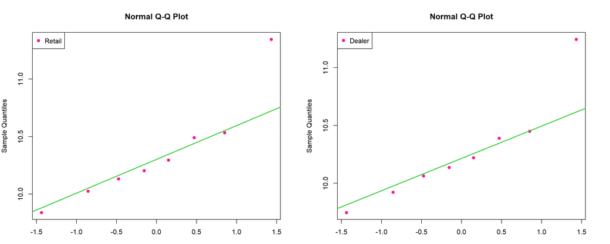

```r
s_front_w_data <- subset(sport_data, Front_wheel == 1)

par(mfrow = c(1,2), mar = c(3, 4, 4, 3))

plot_qq_graph(s_front_w_data$Retail, "Retail")
plot_qq_graph(s_front_w_data$Dealer, "Dealer")
```

```r
test_lillie <- lillie.test(s_front_w_data$Retail)
test_ad <- ad.test(s_front_w_data$Retail)
test_shapiro <- shapiro.test(s_front_w_data$Retail)

test_n_retail <- data.frame(
  Критерий = c("lillie.test", "ad.test", "shapiro.test"),
  Статистика = c(test_lillie$statistic, test_ad$statistic, test_shapiro$statistic),
  p_value = c(test_lillie$p.value, test_ad$p.value, test_shapiro$p.value)
)

print_df(test_n_retail)
```

|  | Критерий | Статистика | p_value |
| --- | --- | --- | --- |
| D | lillie.test | 0.2265312 | 0.2633144 |
| A | ad.test | 0.4620884 | 0.1845214 |
| W | shapiro.test | 0.8768045 | 0.1754894 |

```r
test_lillie <- lillie.test(s_front_w_data$Dealer)
test_ad <- ad.test(s_front_w_data$Dealer)
test_shapiro <- shapiro.test(s_front_w_data$Dealer)

test_n_dealer <- data.frame(
  Критерий = c("lillie.test", "ad.test", "shapiro.test"),
  Статистика = c(test_lillie$statistic, test_ad$statistic, test_shapiro$statistic),
  p_value = c(test_lillie$p.value, test_ad$p.value, test_shapiro$p.value)
)

print_df(test_n_dealer)
```

|  | Критерий | Статистика | p_value |
| --- | --- | --- | --- |
| D | lillie.test | 0.2237349 | 0.2804999 |
| A | ad.test | 0.4345775 | 0.2200915 |
| W | shapiro.test | 0.8855848 | 0.2127788 |

**Передний привод для внедорожников**

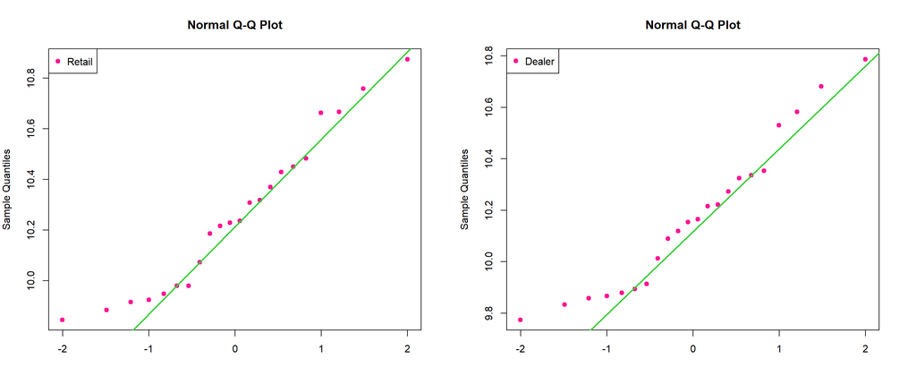

```r
su_front_w_data <- subset(sport_util_data, Front_wheel == 1)

par(mfrow = c(1,2), mar = c(3, 4, 4, 3))

plot_qq_graph(su_front_w_data$Retail, "Retail")
plot_qq_graph(su_front_w_data$Dealer, "Dealer")
```

```r
test_lillie <- lillie.test(su_front_w_data$Retail)
test_ad <- ad.test(su_front_w_data$Retail)
test_shapiro <- shapiro.test(su_front_w_data$Retail)

test_n_retail <- data.frame(
  Критерий = c("lillie.test", "ad.test", "shapiro.test"),
  Статистика = c(test_lillie$statistic, test_ad$statistic, test_shapiro$statistic),
  p_value = c(test_lillie$p.value, test_ad$p.value, test_shapiro$p.value)
)

print_df(test_n_retail)
```

|  | Критерий | Статистика | p_value |
| --- | --- | --- | --- |
| D | lillie.test | 0.1415918 | 0.2999477 |
| A | ad.test | 0.3851607 | 0.3623517 |
| W | shapiro.test | 0.9446272 | 0.2462604 |

```r
test_lillie <- lillie.test(su_front_w_data$Dealer)
test_ad <- ad.test(su_front_w_data$Dealer)
test_shapiro <- shapiro.test(su_front_w_data$Dealer)

test_n_dealer <- data.frame(
  Критерий = c("lillie.test", "ad.test", "shapiro.test"),
  Статистика = c(test_lillie$statistic, test_ad$statistic, test_shapiro$statistic),
  p_value = c(test_lillie$p.value, test_ad$p.value, test_shapiro$p.value)
)

print_df(test_n_dealer)
```

|  | Критерий | Статистика | p_value |
| --- | --- | --- | --- |
| D | lillie.test | 0.1351694 | 0.3700087 |
| A | ad.test | 0.3990499 | 0.3351784 |
| W | shapiro.test | 0.9434182 | 0.2326644 |

То есть при уровне значимсти 0,05 не можем отвергнуть гипотезу о нормальности распределения цены у переднеприводных внедорожников и спортивных машин.

Проверим равенство дисперсий.

```r
var.test(su_front_w_data$Retail, s_front_w_data$Retail, ratio = 1)
```

```
##
##  F test to compare two variances
##
## data:  su_front_w_data$Retail and s_front_w_data$Retail
## F = 0.43203, num df = 21, denom df = 7, p-value = 0.1291
## alternative hypothesis: true ratio of variances is not equal to 1
## 95 percent confidence interval:
##  0.09704105 1.28253994
## sample estimates:
## ratio of variances
##          0.4320309
```

При уровне значимости 0,05 не можем отвергнуть гипотезу о равенстве дисперcии у Retail.

```r
var.test(su_front_w_data$Dealer,  s_front_w_data$Dealer, ratio = 1)
```

```
##
##  F test to compare two variances
##
## data:  su_front_w_data$Dealer and s_front_w_data$Dealer
## F = 0.40431, num df = 21, denom df = 7, p-value = 0.1021
## alternative hypothesis: true ratio of variances is not equal to 1
## 95 percent confidence interval:
##  0.09081542 1.20025905
## sample estimates:
## ratio of variances
##          0.4043141
```

При уровне значимости 0,05 не можем отвергнуть гипотезу о равенстве дисперcии у Dealer.

Посмотрим на описательные статистики для цены у спортивных автомобилей и внедорожников.

**Sport Retail**

```r
variance <- var(s_front_w_data$Retail)
cat("Дисперсия:", variance, "\n")
```

```
## Дисперсия: 0.2120867
```

```r
skew <- skewness(s_front_w_data$Retail)
cat("Асимметрия (Skewness):", skew, "\n")
```

```
## Асимметрия (Skewness): 0.999319
```

```r
kurt <- kurtosis(s_front_w_data$Retail)
cat("Эксцесс (Kurtosis):", kurt, "\n")
```

```
## Эксцесс (Kurtosis): -0.1001228
```

```r
mean_value <- mean(s_front_w_data$Retail)
cat("Среднее:", mean_value, "\n")
```

```
## Среднее: 10.35735
```

```r
median_value <- median(s_front_w_data$Retail)
cat("Медиана:", median_value, "\n")
```

```
## Медиана: 10.24877
```

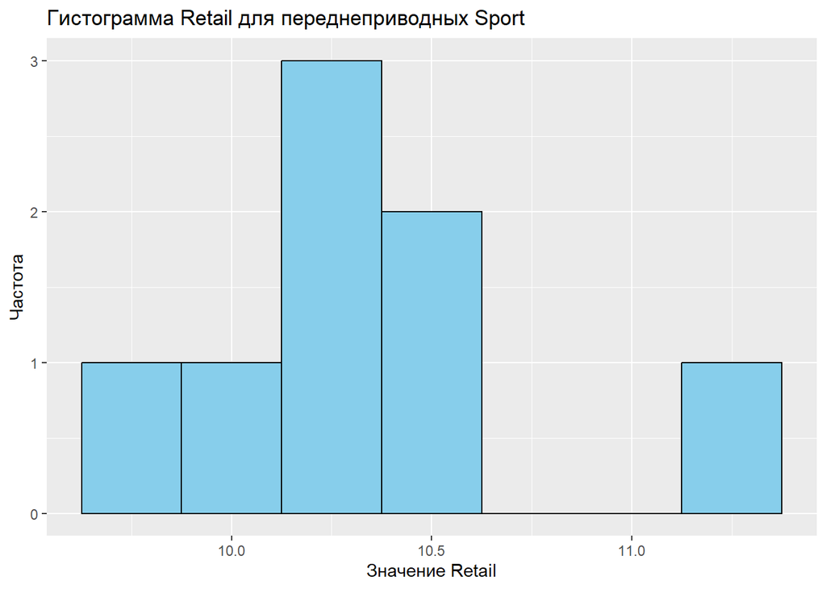

```r
ggplot(s_front_w_data, aes(x = Retail)) +
  geom_histogram(binwidth = 0.25, fill = "skyblue", color = "black") +
  labs(title = "Гистограмма Retail для переднеприводных Sport", x = "Значение Retail", y = "Частота")
```

Эксцес близок к эксцессу нормального распределения, но ассиметрия, близкая к 1, говорит о том, что распределение данных смещено вправо относительно нормального распределения.

**SportUtil Retail**

```r
variance <- var(su_front_w_data$Retail)
cat("Дисперсия:", variance, "\n")
```

```
## Дисперсия: 0.09162802
```

```r
skew <- skewness(su_front_w_data$Retail)
cat("Асимметрия (Skewness):", skew, "\n")
```

```
## Асимметрия (Skewness): 0.3651531
```

```r
kurt <- kurtosis(su_front_w_data$Retail)
cat("Эксцесс (Kurtosis):", kurt, "\n")
```

```
## Эксцесс (Kurtosis): -1.054117
```

```r
mean_value <- mean(su_front_w_data$Retail)
cat("Среднее:", mean_value, "\n")
```

```
## Среднее: 10.26126
```

```r
median_value <- median(su_front_w_data$Retail)
cat("Медиана:", median_value, "\n")
```

```
## Медиана: 10.23305
```

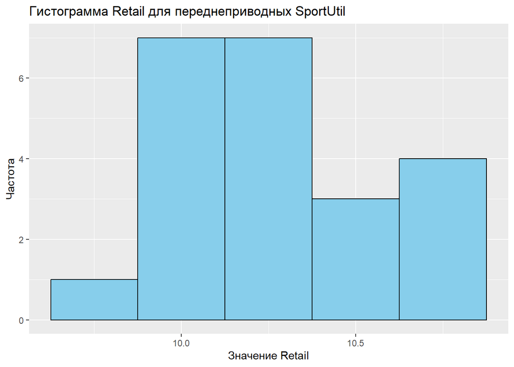

```r
ggplot(su_front_w_data, aes(x = Retail)) +
  geom_histogram(binwidth = 0.25, fill = "skyblue", color = "black") +
  labs(title = "Гистограмма Retail для переднеприводных SportUtil", x = "Значение Retail", y = "Частота")
```

В данном случае ассиметрия не так значительна, а значение эксцесса, примерно равное -1, говорит о менее выраженнных по сравнению с нормальным распределением хвостах.

Дисперсии также имеют небольшое отличие.

Но несмотря на это, тесты не отвергают нормальность и равенство дисперсий.

Проведем t-test без учета равенства дисперсий.

```r
t.test(su_front_w_data$Retail, s_front_w_data$Retail, alternative = "two.sided")
```

```
##
##  Welch Two Sample t-test
##
## data:  su_front_w_data$Retail and s_front_w_data$Retail
## t = -0.54863, df = 9.2957, p-value = 0.5962
## alternative hypothesis: true difference in means is not equal to 0
## 95 percent confidence interval:
##  -0.4903827  0.2982020
## sample estimates:
## mean of x mean of y
##  10.26126  10.35735
```

```r
t.test(su_front_w_data$Dealer, s_front_w_data$Dealer, alternative = "two.sided")
```

```
##
##  Welch Two Sample t-test
##
## data:  su_front_w_data$Dealer and s_front_w_data$Dealer
## t = -0.55487, df = 9.1438, p-value = 0.5923
## alternative hypothesis: true difference in means is not equal to 0
## 95 percent confidence interval:
##  -0.4850737  0.2936167
## sample estimates:
## mean of x mean of y
##  10.17537  10.27110
```

Таким образом, при уровне значимости 0,05 не можем отвергнуть гипотезу о том, что средние равны, так как p-value > 0,05.

Проверим гипотезу о равенстве медиан цены для переднеприводных спортивных машин и переднеприводных внедорожников.

Гипотезу о равенстве медиан можно проверить с помощью теста Манна-Уитни, но изначально этот тест проверяет гипотезу, что выборки взяты из одного распределения, то есть в случае, когда, например, у распределений будут хвосты в разные стороны, но медианы равны, он гипотезу отвергнет, так как распределения разные. Но в случае, если распределения будут иметь одну форму, с помощью Манна-Уитни можно проверить гипотезу о равенстве медиан. Для распределения цены переднеприводных спортивных машин и переднеприводных внедорожников гипотеза о нормальности не отвергается и асимметрия имеет один знак, значит, нет основания полагать, что у этих распределений хвосты будут в разные стороны, следовательно, можем применять Манна-Уитни для проверки гипотезы о равенстве медиан.

Проверим гипотезу о равенстве медиан у Retail с помощью Манна-Уитни.

```r
wilcox.test(su_front_w_data$Retail, s_front_w_data$Retail)
```

```
##
##  Wilcoxon rank sum exact test
##
## data:  su_front_w_data$Retail and s_front_w_data$Retail
## W = 82, p-value = 0.8005
## alternative hypothesis: true location shift is not equal to 0
```

p-value очень большое, поэтому отвергнуть гипотезу о равенстве медиан не можем.

## Сравнение по количеству цилиндров

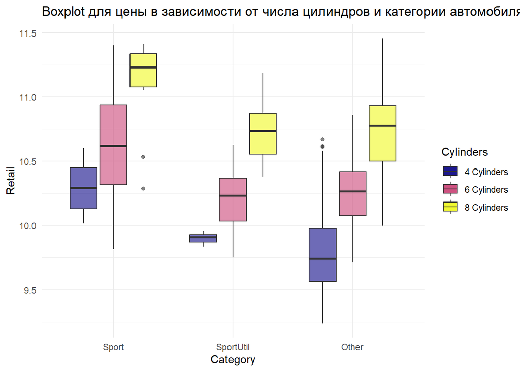

```r
cyl_data <- data_clear %>%
  filter(Cylinders %in% c(4, 6, 8)) %>%
  mutate(Cylinder_type = factor(Cylinders, labels = c("4 Cylinders", "6 Cylinders", "8 Cylinders")))

cyl_sport_data <- cyl_data %>%
  filter(Sport == 1)

cyl_sport_util_data <- cyl_data %>%
  filter(SportUtil == 1)

cyl_other_cars_data <- cyl_data %>%
  filter(Sport == 0 & SportUtil == 0)

ggplot() +
  geom_boxplot(data = cyl_sport_data, aes(x = factor(1), y = Retail, fill = Cylinder_type), alpha = 0.6) +
  geom_boxplot(data = cyl_sport_util_data, aes(x = factor(2), y = Retail, fill = Cylinder_type), alpha = 0.6) +
  geom_boxplot(data = cyl_other_cars_data, aes(x = factor(3), y = Retail, fill = Cylinder_type), alpha = 0.6) +
  scale_x_discrete(labels = c("Sport", "SportUtil", "Other")) +
  scale_fill_viridis(discrete = TRUE, alpha = 0.6, option="C", name = "Cylinders") +
  theme_minimal() +
  labs(title = "Boxplot для цены в зависимости от числа цилиндров и категории автомобиля", x = "Category", y = "Retail")
```

Ничего удивительного мы не получили, для всех данных был получен тот же самый результат.

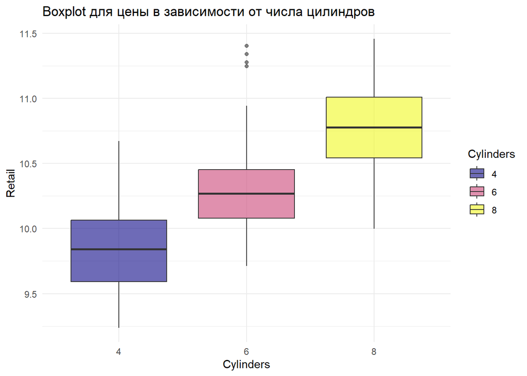

```r
 plot3 <- data_clear %>%
  filter(Cylinders %in% c(4, 6, 8)) %>%
  ggplot(aes(x = as.factor(Cylinders), y = Retail, fill = as.factor(Cylinders))) +
  geom_boxplot(alpha = 0.6) +
  scale_fill_viridis(discrete = TRUE, alpha=0.6, option="C", name = "Cylinders") +
  theme_minimal() +
  labs(title = "Boxplot для цены в зависимости от числа цилиндров", x = "Cylinders", y = "Retail")

 plot3
```

## 2. Сравнение цен Dealer и Retail по критериям и с помощью boxplot

Будем проводить сравнение для машин без учета внедорожников и спортивных автомобилей.

**Визуальное сравнение**

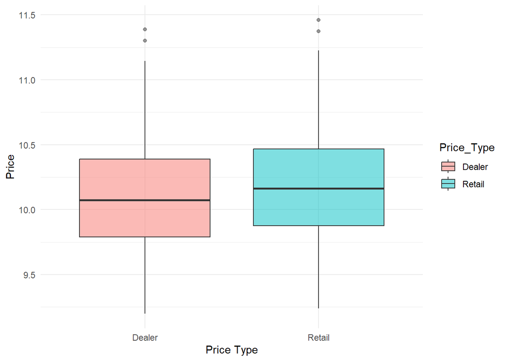

```r
other_cars_data_long <- tidyr::gather(other_cars_data, key = "Price_Type", value = "Price", Dealer, Retail)

ggplot(other_cars_data_long, aes(x = Price_Type, y = Price, fill = Price_Type)) +
  geom_boxplot(alpha = 0.5) +
  labs(x = "Price Type", y = "Price") +
  theme_minimal()
```

Видно, что медиана у Retail больше, чем у Dealer (чего и стоило ожидать).

**Сравнение по критериям**

Проверим гипотезу о равенстве средних у Dealer и Retail. Ожидается, что она должна быть отвергнута, так как цена Retail>Dealer.

Проверим данные на нормальность.Визуально:

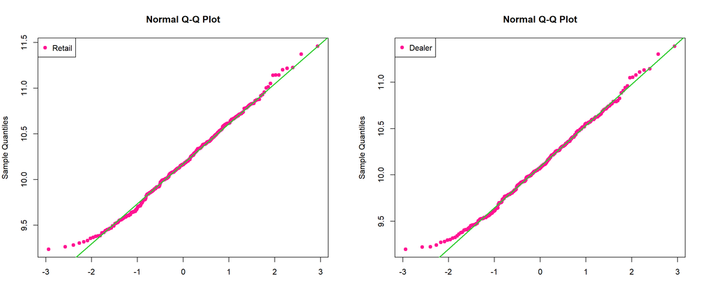

```r
par(mfrow = c(1,2), mar = c(3, 4, 4, 3))

plot_qq_graph(other_cars_data$Retail, "Retail")
plot_qq_graph(other_cars_data$Dealer, "Dealer")
```

На хвостах есть отклонения от нормальности, но в целом признаки похожи на нормально распределенные.

С помощью критериев. Уровень значимости равен 0,05.

```r
test_lillie <- lillie.test(other_cars_data$Retail)
test_ad <- ad.test(other_cars_data$Retail)
test_shapiro <- shapiro.test(other_cars_data$Retail)

test_n_retail <- data.frame(
  Критерий = c("lillie.test", "ad.test", "shapiro.test"),
  Статистика = c(test_lillie$statistic, test_ad$statistic, test_shapiro$statistic),
  p_value = c(test_lillie$p.value, test_ad$p.value, test_shapiro$p.value)
)

print_df(test_n_retail)
```

|  | Критерий | Статистика | p_value |
| --- | --- | --- | --- |
| D | lillie.test | 0.0322537 | 0.6257740 |
| A | ad.test | 0.2869621 | 0.6197275 |
| W | shapiro.test | 0.9928817 | 0.1624150 |

```r
test_lillie <- lillie.test(other_cars_data$Dealer)
test_ad <- ad.test(other_cars_data$Dealer)
test_shapiro <- shapiro.test(other_cars_data$Dealer)

test_n_dealer <- data.frame(
  Критерий = c("lillie.test", "ad.test", "shapiro.test"),
  Статистика = c(test_lillie$statistic, test_ad$statistic, test_shapiro$statistic),
  p_value = c(test_lillie$p.value, test_ad$p.value, test_shapiro$p.value)
)

print_df(test_n_dealer)
```

|  | Критерий | Статистика | p_value |
| --- | --- | --- | --- |
| D | lillie.test | 0.0303985 | 0.7147351 |
| A | ad.test | 0.3319731 | 0.5102940 |
| W | shapiro.test | 0.9917474 | 0.0914757 |

И для Dealer, и для Retail нормальность по всем тестам не отвергается.

```r
t.test(other_cars_data$Dealer, other_cars_data$Retail, paired = TRUE,  alternative = "less")
```

```
##
##  Paired t-test
##
## data:  other_cars_data$Dealer and other_cars_data$Retail
## t = -68.911, df = 300, p-value < 2.2e-16
## alternative hypothesis: true mean difference is less than 0
## 95 percent confidence interval:
##         -Inf -0.07996679
## sample estimates:
## mean difference
##     -0.08192843
```

p-value очень маленькое, значит, гипотеза о равенстве средних отвергается, как и предполагалось.

**Процент, который берет себе ретейлер**

Будем добавлять его к изначальным данным, очищенным от выбросов.

Добавим новый столбец, в котором будут значения процента, который берет себе ретейлер.

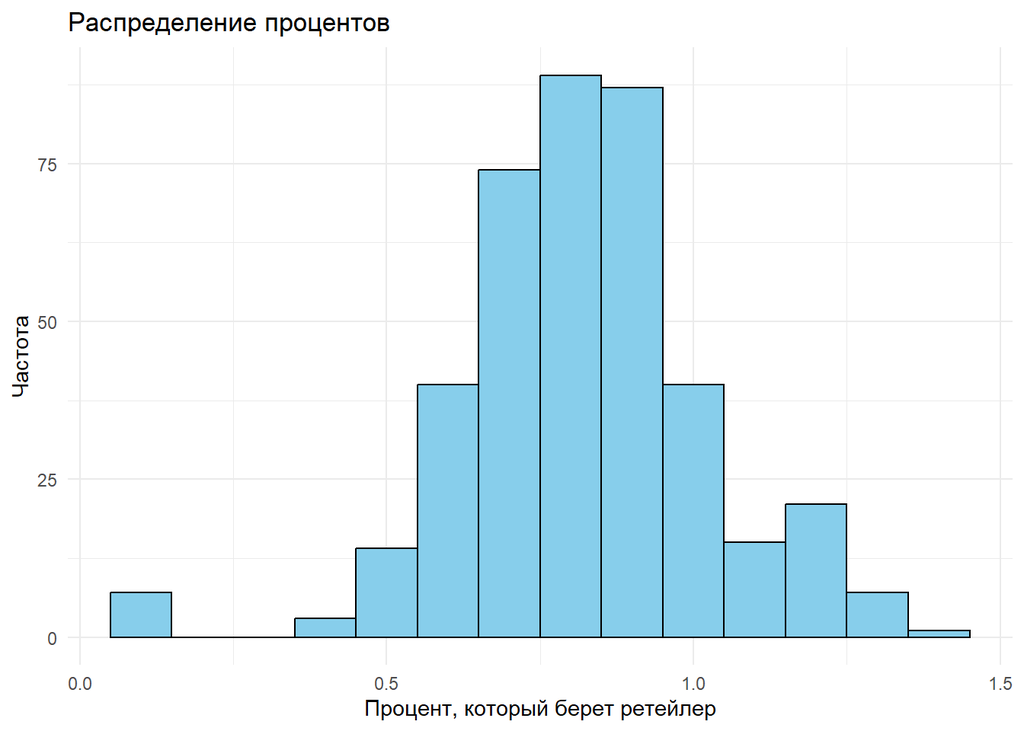

```r
data_clear$Retailer_Percentage <- ((data_clear$Retail - data_clear$Dealer) / data_clear$Retail) * 100

ggplot(data_clear, aes(x = Retailer_Percentage)) +
  geom_histogram(binwidth = 0.1, fill = "skyblue", color = "black") +
  labs(title = "Распределение процентов", x = "Процент, который берет ретейлер", y = "Частота") +
  theme(panel.background = element_rect(fill = "white"), panel.grid.major = element_line(color = "gray", linetype = "dashed")) +
  theme_minimal()
```

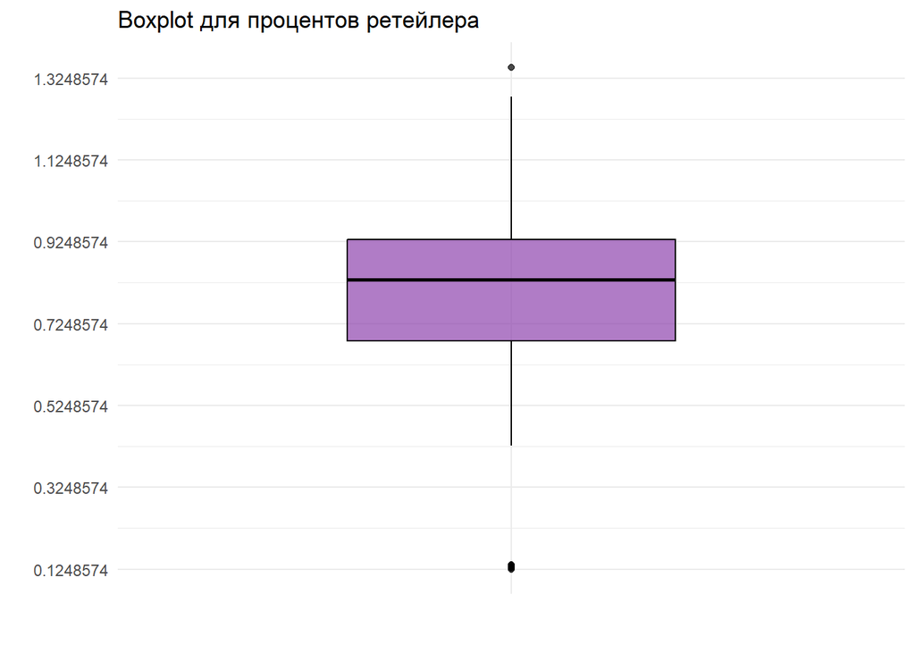

```r
ggplot(data_clear, aes(x = "", y = Retailer_Percentage)) +
  geom_boxplot(width = 0.5, fill = "#8E44AD", alpha = 0.7, color = "black") +
  labs(title = "Boxplot для процентов ретейлера", y="", x = "") +
  scale_y_continuous(breaks = seq(min(data_clear$Retailer_Percentage), max(data_clear$Retailer_Percentage), by = 0.2)) +
  theme_minimal()
```

Ретейлер обычно берет себе ~0,4–1,3%. Рассмотрим наблюдения, для которых процент очень маленький и очень большой:

```r
filtered_data_min <- data_clear %>% filter(Retailer_Percentage < 0.4)

print_df(filtered_data_min)
```

| Name | Retail | Dealer | Engine | Horsepower | CityMPG | HW_MPG | Weight | WheelBase | Length | Width | Other | Front_wheel | Body_type | Wheel_type | Sport | SportUtil | Wagon | Minivan | Pickup | All_wheel | Rear_wheel | Cylinders | Retailer_Percentage |
| --- | --- | --- | --- | --- | --- | --- | --- | --- | --- | --- | --- | --- | --- | --- | --- | --- | --- | --- | --- | --- | --- | --- | --- |
| Suzuki Aeno S 4dr | 9.463741 | 9.450852 | 0.8329091 | 5.043425 | 3.218876 | 3.433987 | 7.892078 | 4.584968 | 171 | 68 | 1 | 1 | 6 | Front-wheel | 0 | 0 | 0 | 0 | 0 | 0 | 0 | 4 | 0.1361966 |
| Suzuki Aerio LX 4dr | 9.581904 | 9.569203 | 0.8329091 | 5.043425 | 3.218876 | 3.433987 | 7.892078 | 4.584968 | 171 | 68 | 1 | 1 | 6 | Front-wheel | 0 | 0 | 0 | 0 | 0 | 0 | 0 | 4 | 0.1325520 |
| Suzuki Forenza S 4dr | 9.414831 | 9.402282 | 0.6931472 | 4.779123 | 3.178054 | 3.433987 | 7.901377 | 4.624973 | 177 | 68 | 1 | 1 | 6 | Front-wheel | 0 | 0 | 0 | 0 | 0 | 0 | 0 | 4 | 0.1332882 |
| Suzuki Forenza EX 4dr | 9.652973 | 9.640693 | 0.6931472 | 4.779123 | 3.091042 | 3.401197 | 7.921536 | 4.624973 | 177 | 68 | 1 | 1 | 6 | Front-wheel | 0 | 0 | 0 | 0 | 0 | 0 | 0 | 4 | 0.1272106 |
| Suzuki Verona LX 4dr | 9.756263 | 9.744081 | 0.9162907 | 5.043425 | 2.995732 | 3.295837 | 8.125631 | 4.663439 | 188 | 72 | 1 | 1 | 6 | Front-wheel | 0 | 0 | 0 | 0 | 0 | 0 | 0 | 6 | 0.1248574 |
| Suzuki Vitara LX | 9.750511 | 9.737964 | 0.9162907 | 5.105945 | 2.944439 | 3.091042 | 8.013012 | 4.584968 | 163 | 67 | 0 | 0 | 2 | All-wheel | 0 | 1 | 0 | 0 | 0 | 1 | 0 | 6 | 0.1286811 |
| Suzuki Aerio SX | 9.710934 | 9.698368 | 0.8329091 | 5.043425 | 3.178054 | 3.367296 | 7.983440 | 4.584968 | 167 | 68 | 0 | 0 | 3 | All-wheel | 0 | 0 | 1 | 0 | 0 | 1 | 0 | 4 | 0.1293978 |

Все наблюдения с маленьким процентом ретейлера одной марки, но чем вызвана такая маленькая наценка не до конца ясно.

```r
filtered_data_max <- data_clear %>% filter(Retailer_Percentage > 1.3)

print_df(filtered_data_max)
```

| Name | Retail | Dealer | Engine | Horsepower | CityMPG | HW_MPG | Weight | WheelBase | Length | Width | Other | Front_wheel | Body_type | Wheel_type | Sport | SportUtil | Wagon | Minivan | Pickup | All_wheel | Rear_wheel | Cylinders | Retailer_Percentage |
| --- | --- | --- | --- | --- | --- | --- | --- | --- | --- | --- | --- | --- | --- | --- | --- | --- | --- | --- | --- | --- | --- | --- | --- |
| Porsche 911 Carrera 4S coupe 2dr (convert) | 11.34053 | 11.18728 | 1.280934 | 5.752573 | 2.833213 | 3.178054 | 8.083329 | 4.532599 | 175 | 72 | 0 | 0 | 1 | All-wheel | 1 | 0 | 0 | 0 | 0 | 1 | 0 | 6 | 1.3514 |

Наблюдение с самой большой наценкой – это Porsche, для этой машины такая наценка не кажется необычной.

## 3. Проверка на нормальность признаков

Будем проводить сравнение для машин без учета внедорожников и спортивных автомобилей.

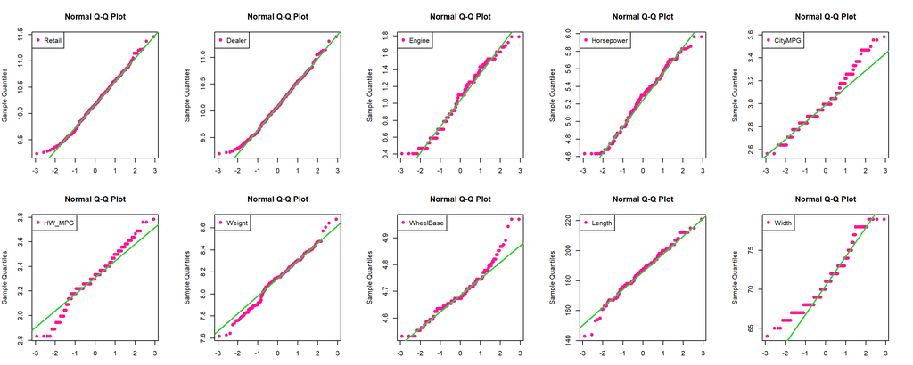

```r
par(mfrow = c(2,5), mar = c(3, 4, 4, 3))

plot_qq_graph(other_cars_data$Retail, "Retail")
plot_qq_graph(other_cars_data$Dealer, "Dealer")
plot_qq_graph(other_cars_data$Engine, "Engine")
plot_qq_graph(other_cars_data$Horsepower, "Horsepower")
plot_qq_graph(other_cars_data$CityMPG, "CityMPG")
plot_qq_graph(other_cars_data$HW_MPG, "HW_MPG")
plot_qq_graph(other_cars_data$Weight, "Weight")
plot_qq_graph(other_cars_data$WheelBase, "WheelBase")
plot_qq_graph(other_cars_data$Length, "Length")
plot_qq_graph(other_cars_data$Width, "Width")
```

```r
normality_tests <- function(data, feature_name) {
  test_lillie <- lillie.test(data)
  test_ad <- ad.test(data)
  test_shapiro <- shapiro.test(data)


  results_df <- data.frame(
    Признак = feature_name,
    p_value_Lilliefors = test_lillie$p.value,
    p_value_Anderson_Darling = test_ad$p.value,
    p_value_Shapiro_Wilk = test_shapiro$p.value
  )

  return(results_df)
}


features <- list(
  Retail = other_cars_data$Retail,
  Dealer = other_cars_data$Dealer,
  Engine = other_cars_data$Engine,
  Horsepower = other_cars_data$Horsepower,
  CityMPG = other_cars_data$CityMPG,
  HW_MPG = other_cars_data$HW_MPG,
  Weight = other_cars_data$Weight,
  WheelBase = other_cars_data$WheelBase,
  Length = other_cars_data$Length,
  Width = other_cars_data$Width
)

results_list <- lapply(names(features), function(feature) {
  normality_tests(features[[feature]], feature)
})


results_df <- do.call(rbind, results_list)
rownames(results_df) <- NULL

print_df(results_df)
```

| Признак | p_value_Lilliefors | p_value_Anderson_Darling | p_value_Shapiro_Wilk |
| --- | --- | --- | --- |
| Retail | 0.6257740 | 0.6197275 | 0.1624150 |
| Dealer | 0.7147351 | 0.5102940 | 0.0914757 |
| Engine | 0.0000006 | 0.0001182 | 0.0002121 |
| Horsepower | 0.0000625 | 0.0037952 | 0.0027008 |
| CityMPG | 0.0000000 | 0.0000000 | 0.0000003 |
| HW_MPG | 0.0000000 | 0.0000014 | 0.0000549 |
| Weight | 0.0000556 | 0.0000134 | 0.0017118 |
| WheelBase | 0.0000000 | 0.0000000 | 0.0000001 |
| Length | 0.1695673 | 0.0608516 | 0.0437004 |
| Width | 0.0000000 | 0.0000000 | 0.0000000 |

Стоило ожидать, что для Engine, CityMPG, HW_MPG, WheelBase, Width гипотеза о нормальности отвергнется, так как они – дискретные признаки. Horsepower тоже скорее дискретный признак, нежеди непрерывный, для него нормальность тоже отвергаеся.

Интересные результаты получились для Weight и Length.

По графику можно было бы предположить, что распределение Weight близко к нормальному, но отклонения на хвостах вносят слишком весомый вклад, поэтому все три теста отвергают нормальность.

Length – дискретный признак, но для него при уровне значимости 0,01 гипотеза о нормальности не может быть отвергнута ни по одному из тестов, а при 0,05 ее отвергнет только тест Шапиро-Уилка. Также на np-plot он выглядит довольно близким к нормальному.

## Часть 3. Об анализе зависимостей

Так как данные неоднородны, рассмотрим отдельно группу **SportUtil**.

Посмотрим на количество пропусков и объем выборки:

```r
num_rows <- nrow(sport_util_data)
print(num_rows)
```

```
## [1] 57
```

```r
rows_with_missing <- sum(!complete.cases(sport_util_data))
print(rows_with_missing)
```

```
## [1] 2
```

```r
missing_per_column <- colSums(is.na(sport_util_data))
variables_with_missing <- names(missing_per_column)[missing_per_column > 0]
print(variables_with_missing)
```

```
## [1] "WheelBase"
```

Так как пропуска всего 2, то сразу уберем их из рассмотрения. Относительно объема выборки они составляют ~3,5%.

```r
sport_util_data |>
  filter(!is.na(WheelBase)) |>
  select(-Name) |>
  scatterPlotMatrix(regressionType = 1,
                        corrPlotType = "Text",
                        categorical = categories,
                        plotProperties = list(noCatColor = "Indigo"),
                        slidersPosition = list(dimCount = 10, xStartingDimIndex = 1, yStartingDimIndex = 1),
                        controlWidgets = TRUE,
                        height = 1200, width = 1250)
```

[interactive chart not shown]

Так как выбросы удалялись для всех данных, а не для групп однородности, в группе SportUtil присутствуют выделяющиеся наблюдения, посмотрим на них.

```r
su_out1 <- sport_util_data %>%
  filter(Length < 160 | Length > 215 | WheelBase > 4.85)

print_df(su_out1)
```

| Name | Retail | Dealer | Engine | Horsepower | CityMPG | HW_MPG | Weight | WheelBase | Length | Width | Other | Front_wheel | Body_type | Wheel_type | Sport | SportUtil | Wagon | Minivan | Pickup | All_wheel | Rear_wheel | Cylinders |
| --- | --- | --- | --- | --- | --- | --- | --- | --- | --- | --- | --- | --- | --- | --- | --- | --- | --- | --- | --- | --- | --- | --- |
| Chevrolet Suburban 1500 LT | 10.66277 | 10.53001 | 1.667707 | 5.686975 | 2.639057 | 2.890372 | 8.506537 | 4.867534 | 219 | 79 | 0 | 1 | 2 | Front-wheel | 0 | 1 | 0 | 0 | 0 | 0 | 0 | 8 |
| GMC Envoy XUV SLE | 10.37005 | 10.27236 | 1.435085 | 5.616771 | 2.708050 | 2.944439 | 8.506132 | 4.859812 | 208 | 75 | 0 | 1 | 2 | Front-wheel | 0 | 1 | 0 | 0 | 0 | 0 | 0 | 6 |
| GMC Yukon XL 2500 SLT | 10.74214 | 10.60990 | 1.791759 | 5.783825 | 2.564949 | 2.833213 | 8.721439 | 4.867534 | 219 | 79 | 0 | 0 | 2 | All-wheel | 0 | 1 | 0 | 0 | 0 | 1 | 0 | 8 |
| Isuzu Ascender S | 10.36876 | 10.30819 | 1.435085 | 5.616771 | 2.708050 | 2.995732 | 8.510571 | 4.859812 | 208 | 76 | 0 | 0 | 2 | All-wheel | 0 | 1 | 0 | 0 | 0 | 1 | 0 | 6 |
| Jeep Wrangler Sahara convertible 2dr | 10.14722 | 10.05514 | 1.386294 | 5.247024 | 2.772589 | 2.944439 | 8.181721 | 4.532599 | 150 | 67 | 0 | 0 | 2 | All-wheel | 0 | 1 | 0 | 0 | 0 | 1 | 0 | 6 |

У Chevrolet Suburban есть страничка на Википедии и звезда на “Аллее Славы” за вклад в развитие кинематографа. Можно ли считать, что он outlier после этого? Это один из самых больших внедорожников на рынке, он выделяется на фоне остальных, поэтому удалим его.

GMC Yukon XL 2500 SLT уже странички в Википедии не имеет, но обладает комплектацией SLT, которая представляет собой более высокий уровень оснащения по сравнению с базовыми версиями автомобилей. Этот внедорожник тоже достаточно крупный, поэтому его также удалим.

Jeep Wrangler Sahara convertible 2dr наоборот является очень компактным внедорожником, также выделяется относительно остальныых машин в выборке.

GMC Envoy XUV SLE, Isuzu Ascender S большое расстояние между передними и задними колесами объясняется особенностями моделей.

```r
sport_util_data <- sport_util_data %>%
  filter(Length >= 160 & Length <= 215 & WheelBase <= 4.85)
```

# Проверка на нормальность SportUtil

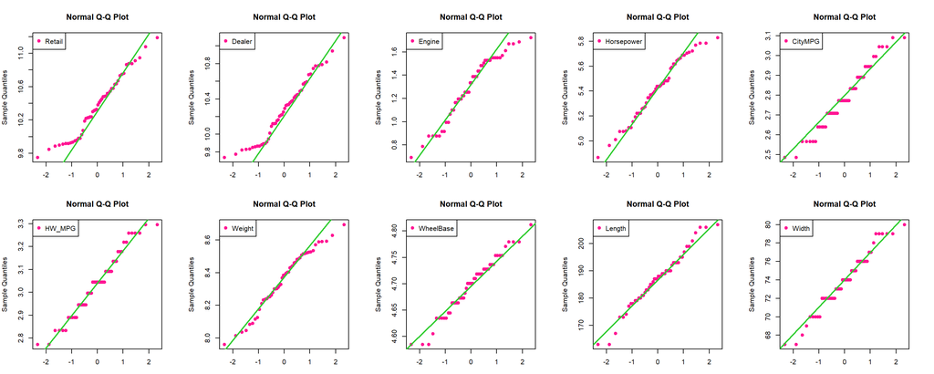

```r
par(mfrow = c(2,5), mar = c(3, 4, 4, 3))

plot_qq_graph(sport_util_data$Retail, "Retail")
plot_qq_graph(sport_util_data$Dealer, "Dealer")
plot_qq_graph(sport_util_data$Engine, "Engine")
plot_qq_graph(sport_util_data$Horsepower, "Horsepower")
plot_qq_graph(sport_util_data$CityMPG, "CityMPG")
plot_qq_graph(sport_util_data$HW_MPG, "HW_MPG")
plot_qq_graph(sport_util_data$Weight, "Weight")
plot_qq_graph(sport_util_data$WheelBase, "WheelBase")
plot_qq_graph(sport_util_data$Length, "Length")
plot_qq_graph(sport_util_data$Width, "Width")
```

```r
normality_tests <- function(data, feature_name) {
  test_lillie <- lillie.test(data)
  test_ad <- ad.test(data)
  test_shapiro <- shapiro.test(data)


  results_df <- data.frame(
    Признак = feature_name,
    p_value_Lilliefors = test_lillie$p.value,
    p_value_Anderson_Darling = test_ad$p.value,
    p_value_Shapiro_Wilk = test_shapiro$p.value
  )

  return(results_df)
}


features <- list(
  Retail = sport_util_data$Retail,
  Dealer = sport_util_data$Dealer,
  Engine = sport_util_data$Engine,
  Horsepower = sport_util_data$Horsepower,
  CityMPG = sport_util_data$CityMPG,
  HW_MPG = sport_util_data$HW_MPG,
  Weight = sport_util_data$Weight,
  WheelBase = sport_util_data$WheelBase,
  Length = sport_util_data$Length,
  Width = sport_util_data$Width
)

results_list <- lapply(names(features), function(feature) {
  normality_tests(features[[feature]], feature)
})


results_df <- do.call(rbind, results_list)
rownames(results_df) <- NULL

print_df(results_df)
```

| Признак | p_value_Lilliefors | p_value_Anderson_Darling | p_value_Shapiro_Wilk |
| --- | --- | --- | --- |
| Retail | 0.1064411 | 0.1431185 | 0.1105194 |
| Dealer | 0.1340677 | 0.1208313 | 0.0726739 |
| Engine | 0.0840962 | 0.0269961 | 0.0333959 |
| Horsepower | 0.5740606 | 0.4324914 | 0.3297328 |
| CityMPG | 0.1052315 | 0.2455786 | 0.2314187 |
| HW_MPG | 0.2348634 | 0.2117341 | 0.1637880 |
| Weight | 0.5634177 | 0.2370856 | 0.2513272 |
| WheelBase | 0.2766524 | 0.4525883 | 0.4563116 |
| Length | 0.6674785 | 0.6436421 | 0.5405930 |
| Width | 0.1782036 | 0.2401056 | 0.2437626 |

При уровне значимости 0,05 нет основания отвергать гипотезу о нормальности у всех признаков, кроме Engine.

# Зависимости признаков

```r
sport_util_data |>
  filter(!is.na(WheelBase)) |>
  select(-Name) |>
  scatterPlotMatrix(regressionType = 1,
                        corrPlotType = "Text",
                        categorical = categories,
                        plotProperties = list(noCatColor = "Indigo"),
                        slidersPosition = list(dimCount = 10, xStartingDimIndex = 1, yStartingDimIndex = 1),
                        controlWidgets = TRUE,
                        height = 1200, width = 1250)
```

[interactive chart not shown]

Все признаки попарно довольно сильно коррелируют.

Видно, что Retail и Dealer максимально линейно зависимы (чего и стоило ожидать), также довольная сильная положительная зависимость видна y CityMPG и HW_MPG (что тоже неудивительно), у Weight и Width. Корреляция Horsepower и MPG; MPG и Weight высокая отрицательная.

Также видна положительная зависимость между Lenght и Width; WheelBase и Lenght, Width; отрицательная между Engine и MPG.

*Коэффициент корреляции Пирсона и Спирмена для группы SportUtil*

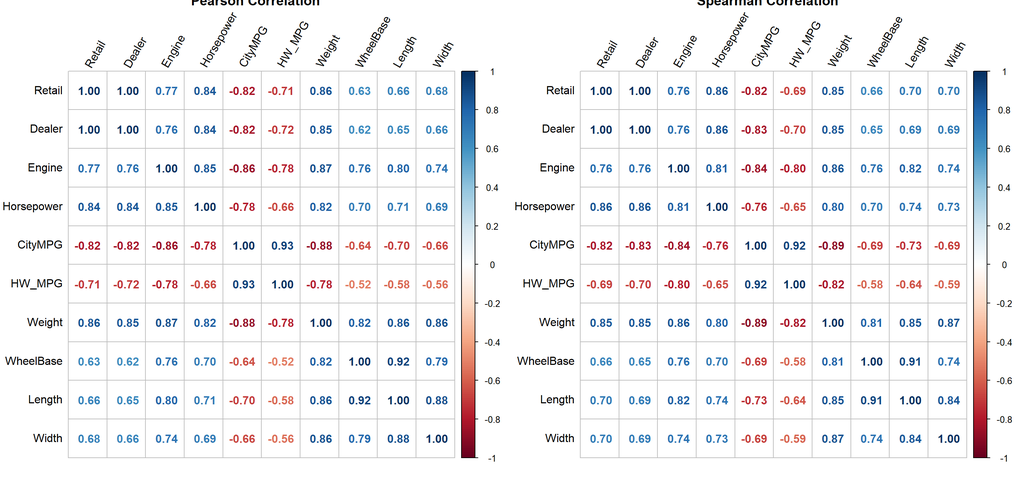

```r
cor_matrix_pearson <- sport_util_data %>%
  filter(!is.na(WheelBase)) %>%
  select(Retail, Dealer, Engine, Horsepower, CityMPG, HW_MPG, Weight, WheelBase, Length, Width) %>%
  cor()

cor_matrix_spearman <- sport_util_data %>%
  filter(!is.na(WheelBase)) %>%
  select(Retail, Dealer, Engine, Horsepower, CityMPG, HW_MPG, Weight, WheelBase, Length, Width) %>%
  cor(method = "spearman")

par(mfrow = c(1, 2), mar = c(5, 5, 7, 2) + 8)

corrplot(cor_matrix_pearson, method = "number", tl.col = "black", tl.srt = 60,
         title = "Pearson Correlation")

corrplot(cor_matrix_spearman, method = "number", tl.col = "black", tl.srt = 60,
         title = "Spearman Correlation")
```

Значения коэффициентов в случае Спирмена и Пирсона довольно похожи, максимальная разность коэффициентов равна 0,06. Коэффициенты довольно похожи, так как мы не отвергли гипотезу о нормальности распределения всех признаков (кроме Engine), в случае нормальной модели коэффициенты связаны формулой $\rho = 2 \sin\left(\frac{\pi}{6}\rho_s\right)$.

## Интерпретация зависимостей

**Retail и Dealer**

Причиной здесь является цена Dealer, а следствием – Retail: чем дороже машина будет куплена у дилера, тем дороже ее продатут в розницу.

**Horsepower и Retail(Dealer)**

Причина – Horsepower, следствие – Retail(Dealer): чем больше у машины лошадиных сил, тем выше ее стоимость.

**MPG и Retail(Dealer)**

Очень интересная зависимость, так как чем выше mpg, тем больше автомобиль может проехать на одном галлоне топлива, то есть чем больше mpg, тем более экономичный у автомобиля расход топлива, поэтому кажется, что цена на такие автомобили должна быть больше, но на графиках мы видим отрицательную зависимость.

**Horsepower и Engine**

Больший объем двигателя обычно позволяет большему количества топлива сгорать в цилиндрах, что в свою очередь может привести к большей выработке мощности, а значит большей скорости. Engine – причина, Horsepower – следствие.

**MPG и Engine, Horsepower** Чтобы достичь большей топливной экономичности, производители часто используют более компактные и меньшие по объему двигатели, которые могут быть менее мощными, но более эффективными в использовании топлива. Поэтому в случае высокого показателя mpg Engine и Horsepower будут меньше.

Тогда можно предположить, что водители выбирают более мощные и скоростные автомобили, вместо более экономичных, чем и вызвана отрицательная корреляция MPG и Retail(Dealer).

**WheelBase и Length**

Чем больше расстояние между колесами, тем длиннее автомобиль. WheelBase – причина, Length – следствие.

**Length, WheelBase, Width и Weight**

Чем больше, тем он тяжелее, то есть чем больше Length, WheelBase, Width (причина), тем больше Weight (следствие).

**Horsepower и Weight**

Чем больше мощность автомобиля (причина), тем больше его вес (следствие). Чтобы добиться высокой мощности, двигатель, трансмиссия, карданный вал, оси, должны быть увеличены, в виду этого увеличивается вес автомобиля.

## Частные корреляции

Посмотрим на корреляции между переменными **без учета влияния количества цилиндров.**

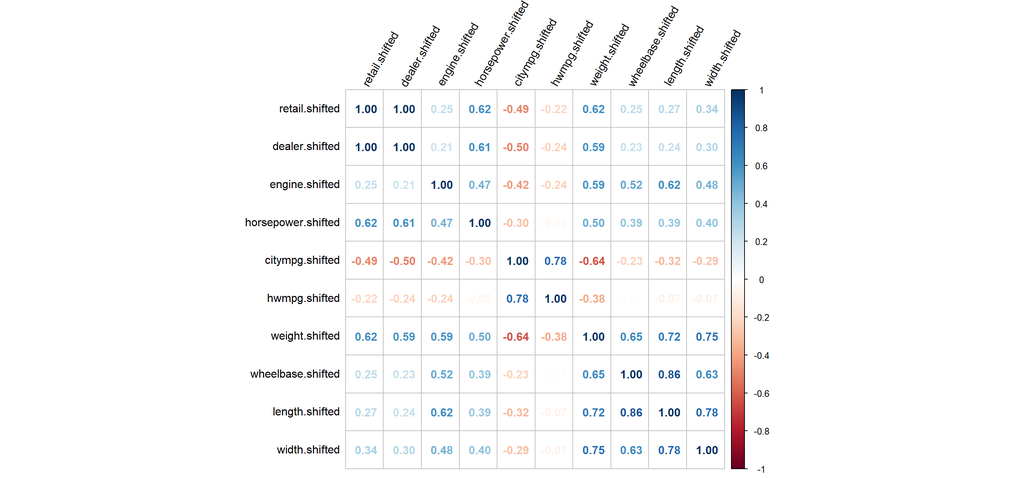

```r
partial.correlation <- function(df, ...) {
  df  |>
    filter(!is.na(Retail) &
             !is.na(Dealer) &
             !is.na(Engine) &
             !is.na(Horsepower) &
             !is.na(CityMPG) &
             !is.na(HW_MPG) &
             !is.na(Weight) &
             !is.na(WheelBase) &
             !is.na(Length) &
             !is.na(Width) &
             !is.na(Cylinders) &
             !is.na(Wheel_type)) |>
    select(-Name) |>
    group_by(...) |>
    mutate(retail.shifted = Retail - mean(Retail),
           dealer.shifted = Dealer - mean(Dealer),
           engine.shifted = Engine - mean(Engine),
           horsepower.shifted = Horsepower - mean(Horsepower),
           citympg.shifted = CityMPG - mean(CityMPG),
           hwmpg.shifted = HW_MPG - mean(HW_MPG),
           weight.shifted = Weight - mean(Weight),
           wheelbase.shifted = WheelBase - mean(WheelBase),
           length.shifted = Length - mean(Length),
           width.shifted = Width - mean(Width)) |>
    group_by(.drop = TRUE) |>
    select(retail.shifted , dealer.shifted, engine.shifted, horsepower.shifted, citympg.shifted, hwmpg.shifted, weight.shifted, wheelbase.shifted, length.shifted, width.shifted) |>
    cor() |>
    corrplot(method = "number", tl.col = "black", tl.srt = 60)
}

partial.correlation(sport_util_data, Cylinders)
```

Корреляции, которые сложно было объяснить, сильно уменьшились и стали практически незначимыми. При этом корреляция между переменными, взаимосвязь между котороми можно объяснить, хоть и немного уменьшилась, но все равно осталась довольно высокой и значимой.

Для сравнения посмотрим на частные корреляции **без учета влияния мощности.**

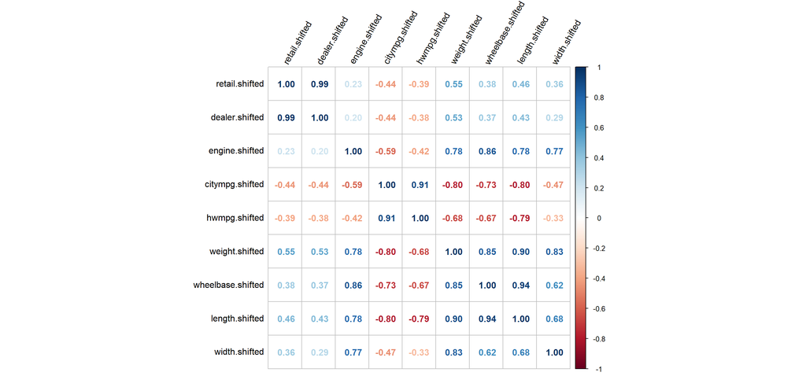

```r
sport_util_data |>
  group_by(Horsepower) |>
  mutate(retail.shifted = Retail - mean(Retail),
           dealer.shifted = Dealer - mean(Dealer),
           engine.shifted = Engine - mean(Engine),
           citympg.shifted = CityMPG - mean(CityMPG),
           hwmpg.shifted = HW_MPG - mean(HW_MPG),
           weight.shifted = Weight - mean(Weight),
           wheelbase.shifted = WheelBase - mean(WheelBase),
           length.shifted = Length - mean(Length),
           width.shifted = Width - mean(Width)) |>
  group_by(.drop = TRUE) |> select(retail.shifted , dealer.shifted, engine.shifted, citympg.shifted, hwmpg.shifted, weight.shifted, wheelbase.shifted, length.shifted, width.shifted) |>
    cor() |>
    corrplot(method = "number", tl.col = "black", tl.srt = 60)
```